# Práctica 1: Hechos estilizados sobre el comportamiento del precio y el rendimiento de los activos

Gibrán Leonardo Chávez González

2026-08-31

# 1. Introducción

En esta práctica se analizará el comportamiento de los precios ajustados y los rendimientos diarios de `Intel (INTC)`, `Nvidia (NVDA)` y `Microsoft (MSFT)` desde enero de 2022. Estos activos fueron seleccionados porque pertenecen al sector tecnológico, pero presentan modelos de negocio y perfiles de riesgo diferentes: Intel se concentra en la fabricación de semiconductores, Nvidia destaca por su crecimiento asociado al cómputo y la inteligencia artificial, mientras que Microsoft posee operaciones más diversificadas. A partir de los rendimientos logarítmicos se evaluarán cuatro hechos estilizados: débil dependencia lineal, agrupamiento de volatilidad, colas pesadas y asimetría. Para ello se utilizarán funciones de autocorrelación, rendimientos cuadrados, distribuciones empíricas y medidas de curtosis y asimetría. La comparación permitirá identificar características comunes y diferencias relevantes para la medición del riesgo financiero.

# 2. Análisis de los hechos estilizados

Para esta práctica, se usarán los siguientes activos: *- Intel (INTC) - NVidia (NVDA) - Microsoft (MSFT)*

Además, hay 4 hechos estilizados que veremos si se cumplen al analizar los siguientes activos, que son los siguientes:

**Hecho 1: Dependencia lineal de los rendimientos**

El rendimiento de ayer normalmente ofrece muy poca información para predecir directamente el rendimiento de hoy.

Por ejemplo, que una acción haya subido ayer no significa necesariamente que hoy volverá a subir ni que hoy bajará. Matemáticamente, esto se expresa como:

$$\operatorname{Corr}(r_t,r_{t-1}) \approx
0.$$

Sin embargo, una correlación cercana a cero no significa independencia total. Puede haber otras relaciones menos evidentes, especialmente en la magnitud de los movimientos.

Es difícil predecir la dirección del próximo rendimiento observando únicamente los rendimientos anteriores.

**Hecho 2: Cluster de volatilidad**

Los periodos turbulentos suelen aparecer juntos, al igual que los periodos tranquilos.

Cuando ocurre un movimiento grande, ya sea positivo o negativo, aumenta la posibilidad de que posteriormente aparezcan otros movimientos grandes. De manera similar, movimientos pequeños suelen ser seguidos por movimientos pequeños.

Por ejemplo:

$$-7\%, \qquad +5\%, \qquad -6\%, \qquad
+4\%$$

indica mucha volatilidad, aunque los signos sean diferentes. Lo persistente no es la dirección, sino la magnitud.

No sabemos necesariamente si el mercado subirá o bajará, pero sí podemos detectar épocas en las que se mueve mucho o poco.

**Hecho 3: Colas pesadas**

Los rendimientos extremos suceden con mayor frecuencia de la que pronosticaría una distribución normal.

Si utilizamos una distribución normal, movimientos como una caída de $8\%$ o $10\%$ podrían parecer extremadamente improbables. En los mercados reales, estos acontecimientos ocurren más veces de lo esperado.

Por eso se dice que la distribución tiene colas pesadas: hay más probabilidad acumulada en los extremos. También puede ser leptocúrtica, con una mayor concentración cerca del centro y, simultáneamente, más observaciones extremas.

Los días aparentemente normales son muy comunes, pero las sorpresas enormes también ocurren con más frecuencia de la que sugiere el modelo normal.

La consecuencia es importante, porque suponer normalidad puede llevarnos a subestimar el riesgo de pérdidas extraordinarias.

**Hecho 4: Asimetría**

Las ganancias y las pérdidas extremas no necesariamente tienen la misma probabilidad ni la misma magnitud.

Una distribución con asimetría negativa presenta una cola izquierda más larga. Esto significa que existe una posibilidad relativamente mayor de observar pérdidas negativas muy grandes.

Dos inversiones pueden tener la misma media y la misma varianza, pero diferentes riesgos. Una podría presentar fluctuaciones equilibradas, mientras que otra tendría normalmente resultados moderados, pero ocasionalmente sufriría una pérdida enorme.

Ganar mucho y perder mucho no son necesariamente riesgos equivalentes; la forma del lado negativo de la distribución importa especialmente para un inversionista.

Ahora importamos las librerías con las que vamos a trabajar:

```r
library(quantmod)
library(moments)
```

Se eligió el periodo de estudio desde el 1 de enero de 2022 porque ofrece suficientes observaciones recientes y comparables para los tres activos y porque el mismo prediodo de análisis para los tres, para que sea más equitativo. Además, incluye etapas de alta volatilidad, corrección y crecimiento tecnológico, lo que permite identificar con mayor claridad los hechos estilizados de sus rendimientos.

## Intel (INTC)

1. Descarga de precios

```r
ticker1 <- 'INTC'

getSymbols(
  ticker1,
  src = 'yahoo',
  from = '2022-01-01'
)
```

```
## [1] "INTC"
```

```r
price1 <- Ad(get(ticker1))
head(price1)
```

```
##            INTC.Adjusted
## 2022-01-03      49.35048
## 2022-01-04      49.28556
## 2022-01-05      49.96262
## 2022-01-06      50.09246
## 2022-01-07      49.56380
## 2022-01-10      51.20543
```

2. Graficar la serie de precios

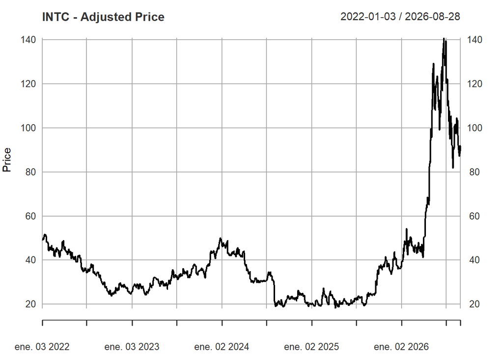

```r
plot(
  price1,
  main = paste(ticker1, '- Adjusted Price'),
  ylab = 'Price',
  xlab = ''
)
```

3. Rendimiento simple y logarítmico

```r
simple_return1 <- dailyReturn(na.omit(price1), type = 'arithmetic')
log_return1 <- dailyReturn(na.omit(price1), type = 'log')

head(cbind(simple_return1, log_return1))
```

```
##            daily.returns daily.returns.1
## 2022-01-03   0.000000000     0.000000000
## 2022-01-04  -0.001315459    -0.001316325
## 2022-01-05   0.013737319     0.013643818
## 2022-01-06   0.002598760     0.002595389
## 2022-01-07  -0.010553529    -0.010609612
## 2022-01-10   0.033121360     0.032584667
```

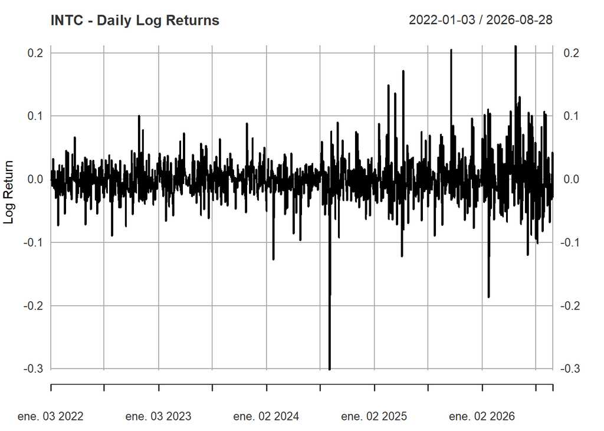

```r
plot(
  log_return1,
  main = paste(ticker1, '- Daily Log Returns'),
  ylab = 'Log Return',
  xlab = ''
)

abline(h = 0, lty = 2)
```

### Hecho 1: Dependencia lineal de los rendimientos

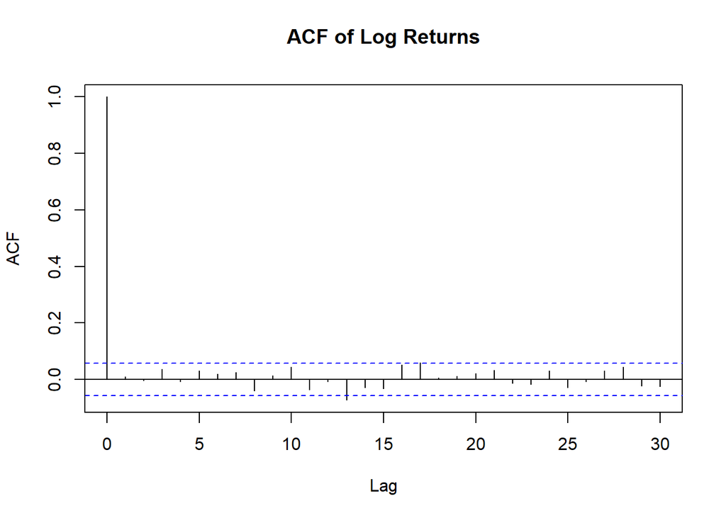

```r
acf(
  na.omit(log_return1),
  main = 'ACF of Log Returns'
)
```

La mayoría de las autocorrelaciones de los rendimientos está cerca de cero y dentro de las bandas de significancia. Los pocos picos aislados no forman un patrón persistente, por lo que los rendimientos pasados tienen escasa capacidad predictiva lineal.

Cabe destacar que, debido al intervalo de confianza del 95% de la gráfica, es esperable que un 5% de los rezagos cruce las bandas por puro ruido estadístico, lo que confirma la ausencia de predictibilidad.

### Hecho 2: Cluster de volatilidad

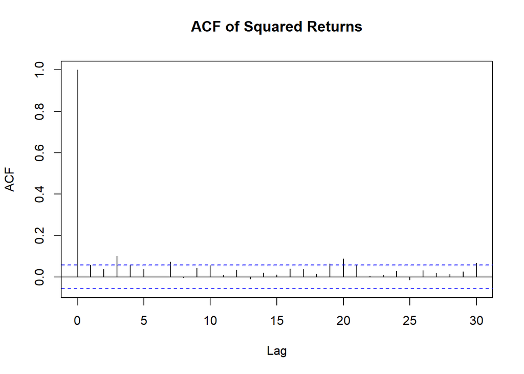

```r
acf(
  na.omit(log_return1)^2,
  main = 'ACF of Squared Returns'
)
```

La ACF de los rendimientos cuadrados presenta algunos coeficientes positivos significativos. Esto sugiere dependencia en la magnitud de los movimientos, aunque los picos son pequeños y poco persistentes, por lo que la evidencia no es contundente.

Esta aparente debilidad visual puede deberse a que el uso de rendimientos al cuadrado amplifica excesivamente los valores atípicos, lo cual oscurece parcialmente la verdadera señal de persistencia en la autocorrelación.

### Hecho 3: Colas pesadas

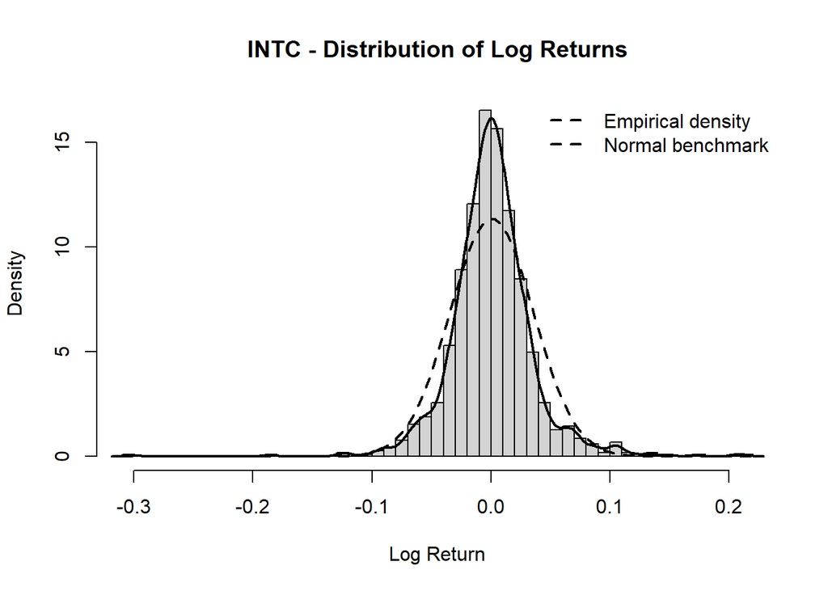

```r
r1 <- as.numeric(na.omit(log_return1))

hist(
  r1,
  breaks = 50,
  probability = TRUE,
  main = paste(ticker1, '- Distribution of Log Returns'),
  xlab = 'Log Return'
)

lines(
  density(r1),
  lwd = 2
)

mu_hat1 <- mean(r1)
sigma_hat1 <- sd(r1)

curve(
  dnorm(x, mean = mu_hat1, sd = sigma_hat1),
  add = TRUE,
  lwd = 2,
  lty = 2
)

legend(
  'topright',
  legend = c('Empirical density', 'Normal benchmark'),
  lty = c(2, 2),
  lwd = c(2, 2),
  bty = 'n'
)
```

La distribución es más puntiaguda y extrema que la normal. La curtosis de 11.699 y el exceso de curtosis de 8.699 confirman una alta frecuencia de rendimientos extremos.

### Hecho 4: Asimetría

```r
mean_return1 <- mean(r1)
sd_return1 <- sd(r1)
skew_return1 <- skewness(r1)
kurt_return1 <- kurtosis(r1)

excess_kurtosis1 <- kurt_return1 - 3

summary_stats1 <- data.frame(
  Mean = mean_return1,
  SD = sd_return1,
  Skwenees = skew_return1,
  Kurtosis = kurt_return1,
  Excess_Kurtosis = excess_kurtosis1
)

summary_stats1
```

```
##         Mean         SD   Skwenees Kurtosis Excess_Kurtosis
## 1 0.00050938 0.03509285 0.02288076 11.69912        8.699124
```

El coeficiente de asimetría es 0.0229, prácticamente cero. Por ello, la distribución puede considerarse aproximadamente simétrica, sin predominio relevante de la cola positiva o negativa.

## NVidia (NVDA)

1. Descarga de precios

```r
ticker2 <- 'NVDA'

getSymbols(
  ticker2,
  src = 'yahoo',
  from = '2022-01-01'
)
```

```
## [1] "NVDA"
```

```r
price2 <- Ad(get(ticker2))
head(price2)
```

```
##            NVDA.Adjusted
## 2022-01-03      30.02614
## 2022-01-04      29.19776
## 2022-01-05      27.51707
## 2022-01-06      28.08926
## 2022-01-07      27.16119
## 2022-01-10      27.31371
```

2. Graficar la serie de precios

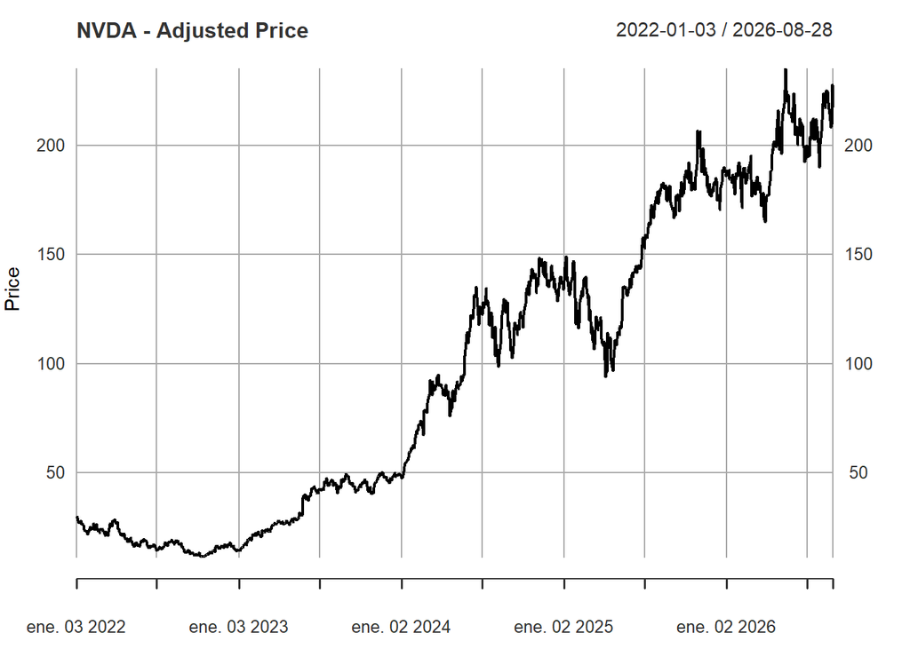

```r
plot(
  price2,
  main = paste(ticker2, '- Adjusted Price'),
  ylab = 'Price',
  xlab = ''
)
```

3. Rendimiento simple y logarítmico

```r
simple_return2 <- dailyReturn(na.omit(price2), type = 'arithmetic')
log_return2 <- dailyReturn(na.omit(price2), type = 'log')

head(cbind(simple_return2, log_return2))
```

```
##            daily.returns daily.returns.1
## 2022-01-03   0.000000000     0.000000000
## 2022-01-04  -0.027588584    -0.027976296
## 2022-01-05  -0.057562381    -0.059285549
## 2022-01-06   0.020794117     0.020580870
## 2022-01-07  -0.033040030    -0.033598181
## 2022-01-10   0.005615196     0.005599489
```

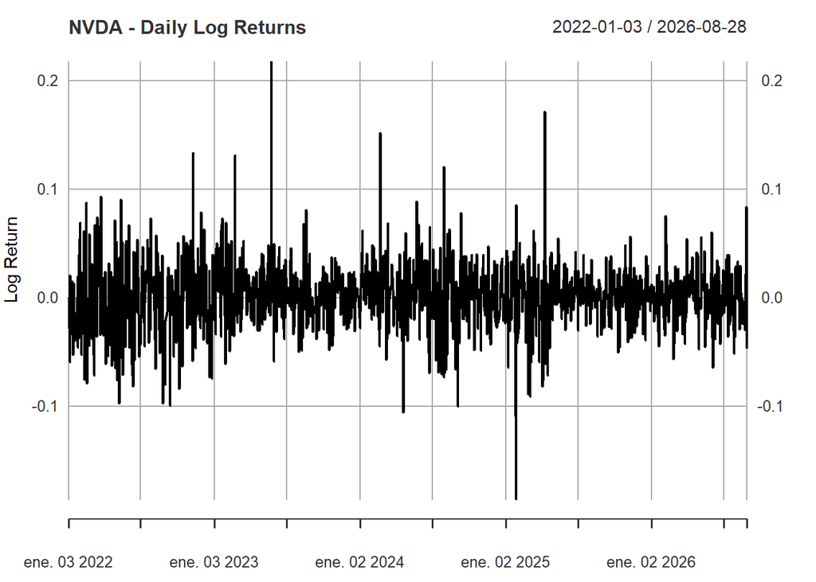

```r
plot(
  log_return2,
  main = paste(ticker2, '- Daily Log Returns'),
  ylab = 'Log Return',
  xlab = ''
)

abline(h = 0, lty = 2)
```

### Hecho 1: Dependencia lineal de los rendimientos

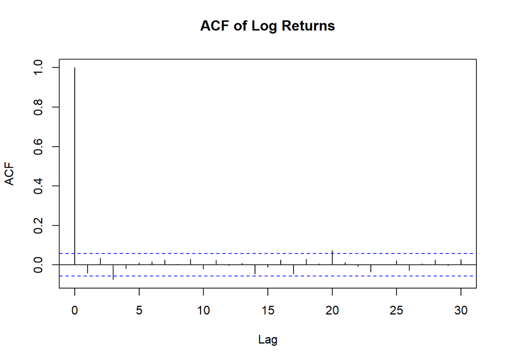

```r
acf(
  na.omit(log_return2),
  main = 'ACF of Log Returns'
)
```

Casi todas las autocorrelaciones están próximas a cero y dentro de las bandas. Aunque existe algún pico aislado, no se observa dependencia lineal persistente; los rendimientos anteriores aportan poca información sobre los futuros.

Este pico aislado es atribuible al ruido estadístico natural (5% de probabilidad) inherente al intervalo de confianza, reafirmando que no hay una señal predictiva real.

### Hecho 2: Cluster de volatilidad

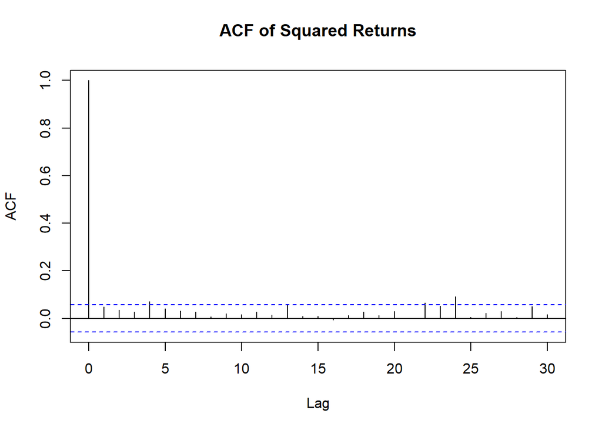

```r
acf(
  na.omit(log_return2)^2,
  main = 'ACF of Squared Returns'
)
```

La serie muestra periodos con distinta intensidad de movimientos y la ACF de rendimientos cuadrados contiene algunos picos positivos significativos. Sin embargo, la dependencia no es prolongada, por lo que la evidencia es moderada.

El método de rendimientos al cuadrado tiende a exagerar los datos extremos (outliers), lo que genera ruido en la gráfica y hace que la dependencia parezca menos prolongada de lo que estructuralmente es.

### Hecho 3: Colas pesadas

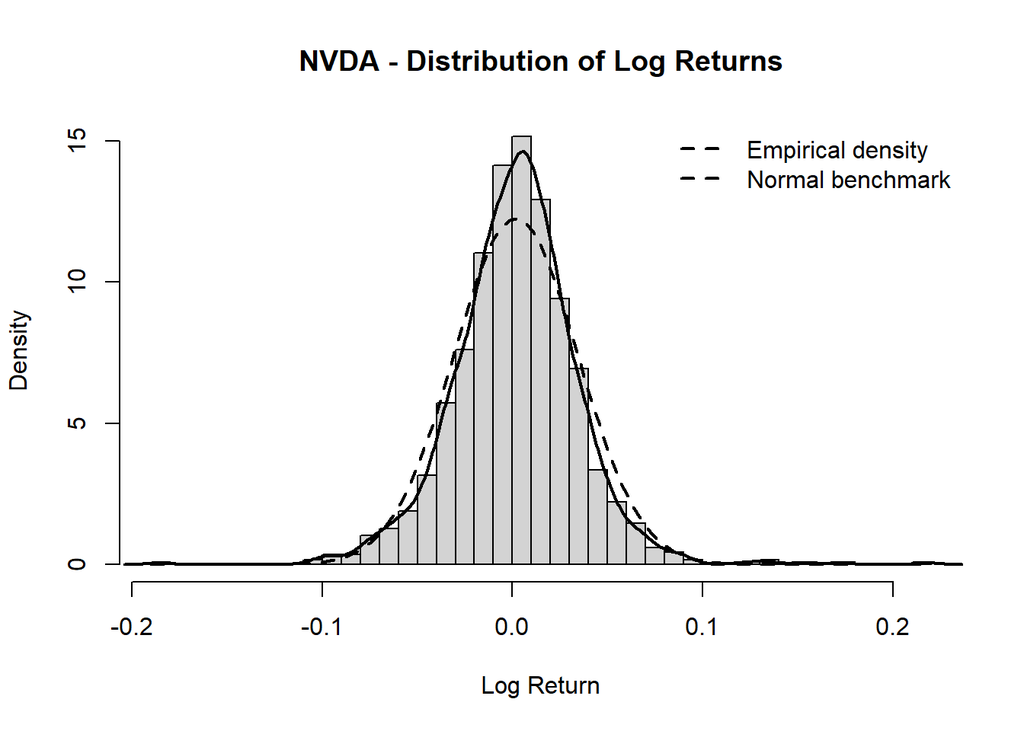

```r
r2 <- as.numeric(na.omit(log_return2))

hist(
  r2,
  breaks = 50,
  probability = TRUE,
  main = paste(ticker2, '- Distribution of Log Returns'),
  xlab = 'Log Return'
)

lines(
  density(r2),
  lwd = 2
)

mu_hat2 <- mean(r2)
sigma_hat2 <- sd(r2)

curve(
  dnorm(x, mean = mu_hat2, sd = sigma_hat2),
  add = TRUE,
  lwd = 2,
  lty = 2
)

legend(
  'topright',
  legend = c('Empirical density', 'Normal benchmark'),
  lty = c(2, 2),
  lwd = c(2, 2),
  bty = 'n'
)
```

La densidad empírica es más puntiaguda y presenta más valores extremos que la normal. La curtosis de 6.874 y el exceso de 3.874 muestran una distribución leptocúrtica.

### Hecho 4: Asimetría

```r
mean_return2 <- mean(r2)
sd_return2 <- sd(r2)
skew_return2 <- skewness(r2)
kurt_return2 <- kurtosis(r2)

excess_kurtosis2 <- kurt_return2 - 3

summary_stats2 <- data.frame(
  Mean = mean_return2,
  SD = sd_return2,
  Skwenees = skew_return2,
  Kurtosis = kurt_return2,
  Excess_Kurtosis = excess_kurtosis2
)

summary_stats2
```

```
##          Mean         SD  Skwenees Kurtosis Excess_Kurtosis
## 1 0.001695514 0.03255181 0.2408724 6.874154        3.874154
```

El coeficiente de asimetría es 0.2409, indicando una cola derecha ligeramente más pronunciada. La distribución permanece relativamente equilibrada, pero los rendimientos positivos extremos tienen algo más de peso.

## Microsoft (MSFT)

1. Descarga de precios

```r
ticker3 <- 'MSFT'

getSymbols(
  ticker3,
  src = 'yahoo',
  from = '2022-01-01'
)
```

```
## [1] "MSFT"
```

```r
price3 <- Ad(get(ticker3))
head(price3)
```

```
##            MSFT.Adjusted
## 2022-01-03      321.8565
## 2022-01-04      316.3376
## 2022-01-05      304.1940
## 2022-01-06      301.7903
## 2022-01-07      301.9442
## 2022-01-10      302.1653
```

2. Graficar la serie de precios

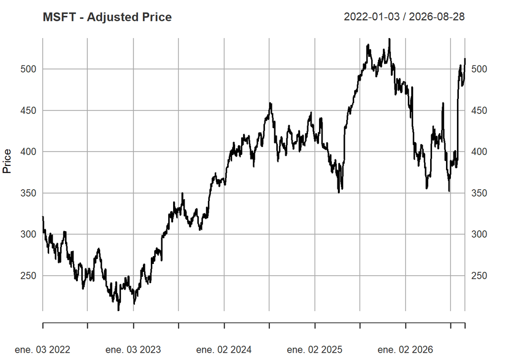

```r
plot(
  price3,
  main = paste(ticker3, '- Adjusted Price'),
  ylab = 'Price',
  xlab = ''
)
```

3. Rendimiento simple y logarítmico

```r
simple_return3 <- dailyReturn(na.omit(price3), type = 'arithmetic')
log_return3 <- dailyReturn(na.omit(price3), type = 'log')

head(cbind(simple_return3, log_return3))
```

```
##            daily.returns daily.returns.1
## 2022-01-03  0.0000000000    0.0000000000
## 2022-01-04 -0.0171471488   -0.0172958637
## 2022-01-05 -0.0383880605   -0.0391442990
## 2022-01-06 -0.0079019221   -0.0079333077
## 2022-01-07  0.0005100584    0.0005099284
## 2022-01-10  0.0007322541    0.0007319861
```

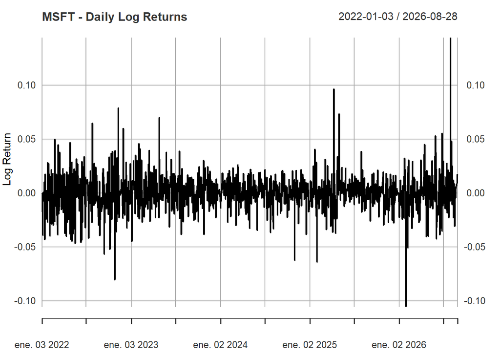

```r
plot(
  log_return3,
  main = paste(ticker3, '- Daily Log Returns'),
  ylab = 'Log Return',
  xlab = ''
)

abline(h = 0, lty = 2)
```

### Hecho 1: Dependencia lineal de los rendimientos

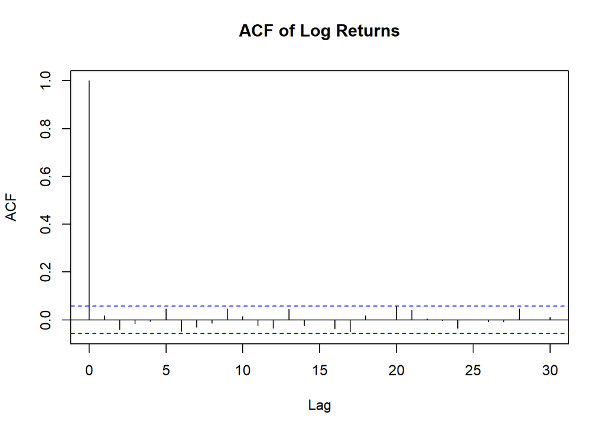

```r
acf(
  na.omit(log_return3),
  main = 'ACF of Log Returns'
)
```

La mayoría de las autocorrelaciones se encuentra cerca de cero y dentro de las bandas. Los picos aislados no muestran continuidad, por lo que existe poca predictibilidad lineal en los rendimientos.

### Hecho 2: Cluster de volatilidad

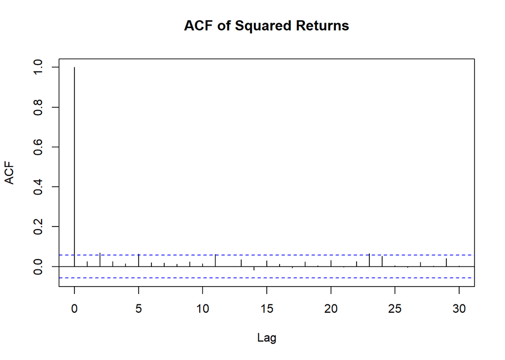

```r
acf(
  na.omit(log_return3)^2,
  main = 'ACF of Squared Returns'
)
```

La gráfica muestra periodos tranquilos y turbulentos, mientras que la ACF de rendimientos cuadrados contiene algunos picos positivos significativos. La magnitud de los movimientos presenta dependencia, aunque no es persistentemente elevada.

Esta caída rápida en la persistencia visual es un efecto secundario de utilizar rendimientos al cuadrado, una métrica que amplifica el ruido de los movimientos extremos y puede subestimar visualmente el clúster.

### Hecho 3: Colas pesadas

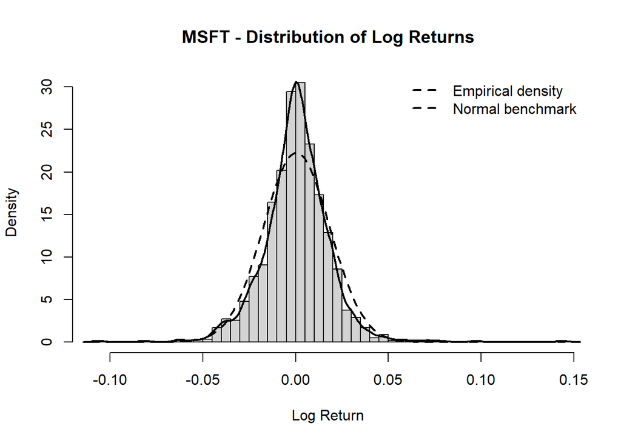

```r
r3 <- as.numeric(na.omit(log_return3))

hist(
  r3,
  breaks = 50,
  probability = TRUE,
  main = paste(ticker3, '- Distribution of Log Returns'),
  xlab = 'Log Return'
)

lines(
  density(r3),
  lwd = 2
)

mu_hat3 <- mean(r3)
sigma_hat3 <- sd(r3)

curve(
  dnorm(x, mean = mu_hat3, sd = sigma_hat3),
  add = TRUE,
  lwd = 2,
  lty = 2
)

legend(
  'topright',
  legend = c('Empirical density', 'Normal benchmark'),
  lty = c(2, 2),
  lwd = c(2, 2),
  bty = 'n'
)
```

La distribución empírica es más puntiaguda y extrema que la normal. La curtosis de 9.257 y el exceso de 6.257 muestran una frecuencia considerablemente mayor de rendimientos extremos.

### Hecho 4: Asimetría

```r
mean_return3 <- mean(r3)
sd_return3 <- sd(r3)
skew_return3 <- skewness(r3)
kurt_return3 <- kurtosis(r3)

excess_kurtosis3 <- kurt_return3 - 3

summary_stats3 <- data.frame(
  Mean = mean_return3,
  SD = sd_return3,
  Skwenees = skew_return3,
  Kurtosis = kurt_return3,
  Excess_Kurtosis = excess_kurtosis3
)

summary_stats3
```

```
##           Mean         SD  Skwenees Kurtosis Excess_Kurtosis
## 1 0.0004000024 0.01790561 0.3653544 9.256635        6.256635
```

El coeficiente de asimetría es 0.3653, lo que indica una cola derecha relativamente más pronunciada. En esta muestra, los rendimientos positivos extremos tienen mayor peso que los negativos.

# 3. Auditoría con IA

## Respuesta de la IA al prompt utilizado

Tu análisis es metodológicamente sólido y tus interpretaciones estadísticas están directamente respaldadas por los resultados de tu código en R.

### Aciertos metodológicos

- La evaluación de la débil dependencia lineal mediante la función de autocorrelación (ACF) de los rendimientos logarítmicos es precisa. Tu deducción sobre la falta de capacidad predictiva lineal es correcta.
- El cálculo para demostrar las colas pesadas es exacto. Al restar 3 a la curtosis bruta, demostraste correctamente el exceso de curtosis ($8.699$ para INTC, $3.874$ para NVDA y $6.257$ para MSFT), confirmando distribuciones leptocúrticas.
- El uso de los rendimientos al cuadrado para detectar el agrupamiento de volatilidad es un procedimiento estándar en econometría financiera.

### Áreas de oportunidad e interpretación

- **Contexto de la asimetría:** clásicamente, uno de los hechos estilizados de los rendimientos de acciones es la presencia de asimetría negativa, ya que los colapsos del mercado suelen ser más rápidos y violentos que las subidas. En tu análisis encontraste asimetría positiva en NVDA ($0.2409$) y MSFT ($0.3653$), mientras que INTC presenta una asimetría cercana a cero ($0.0229$). Metodológicamente, el análisis es correcto, pero la interpretación puede enriquecerse indicando que este resultado corresponde específicamente a la muestra analizada y no necesariamente contradice el comportamiento histórico general del mercado.
- **Robustez del agrupamiento de volatilidad:** concluiste que la evidencia es moderada porque los picos positivos en la ACF de los rendimientos al cuadrado son pequeños. Una posible mejora metodológica sería complementar el análisis con la ACF de los rendimientos absolutos, $|r|$. Los rendimientos al cuadrado amplifican considerablemente los valores atípicos, lo que puede debilitar visualmente la señal de persistencia en la ACF.
- **Picos aislados en la ACF:** señalas correctamente que existen algunos picos aislados en la dependencia lineal que no forman un patrón. También puede mencionarse que, al utilizar bandas de confianza del $95\%$, algunos rezagos pueden superar dichas bandas simplemente por variabilidad muestral. Por ello, la existencia de uno o pocos picos aislados no necesariamente implica capacidad predictiva.

## Oportunidades de mejora

- Lo único que me recomendó la IA, es explicar más las interpretaciones, ya que mencionó lo siguiente:

“Tu análisis original no tiene errores de cálculo matemático, sino ausencias de contexto estadístico y teórico. El ‘fallo’ en tus interpretaciones iniciales es que se limitan a describir literalmente lo que ves en las gráficas o los resultados, pero omiten explicar el mecanismo matemático o económico que justifica esas observaciones.”

# 4. Conclusiones

Los tres activos presentan débil dependencia lineal, pues sus rendimientos pasados ofrecen poca capacidad para predecir los rendimientos futuros. También muestran evidencia moderada de agrupamiento de volatilidad, con periodos de calma y turbulencia que tienden a concentrarse temporalmente. En los tres casos, las distribuciones presentan colas más pesadas que una distribución normal. Intel registra la mayor curtosis y, por tanto, la frecuencia relativa más elevada de rendimientos extremos. Microsoft ocupa una posición intermedia, mientras que Nvidia presenta la menor curtosis de los tres, aunque todavía superior a la normal. La principal diferencia aparece en la asimetría de las distribuciones. Intel es aproximadamente simétrica, mientras que Nvidia muestra asimetría positiva leve y Microsoft una asimetría positiva más marcada. Por ello, la dirección y el peso de los eventos extremos no son iguales para los tres activos. Estos resultados indican que la volatilidad constante y la normalidad son aproximaciones insuficientes para describir completamente sus rendimientos. Utilizar únicamente la media y la desviación estándar podría subestimar la frecuencia y magnitud de pérdidas o ganancias extraordinarias. La medición del riesgo debería incorporar volatilidad variable, distribuciones con colas pesadas y un análisis más específico.